# Lesson 07 - Regression and Regularization

### The following topics are discussed in this notebook:

- Using a neural network for performing regression.
- Feature scaling.
- Applying regularization in a neural network.

```python
import numpy as np
import matplotlib.pyplot as plt
import pandas as pd
import random

import keras
from keras.models import Sequential
from keras.layers import Dense
from tensorflow import set_random_seed

from sklearn.model_selection import train_test_split
```

# Boston Housing Data

In this example, we will be working with the "Boston Housing" dataset. This dataset contains data for 506 census tracts of Boston from the 1970 census.

The dataset contains the following 19 pieces of information for each census tract:

- **`town`** - name of town
- **`tract`** - census tract
- **`lon`** - longitude of census tract
- **`lat`** - latitude of census tract
- **`medv`** - median value of owner-occupied homes in USD 1000's
- **`cmedv`** - corrected median value of owner-occupied homes in USD 1000's
- **`crim`** - per capita crime rate by town
- **`zn`** - proportion of residential land zoned for lots over 25,000 sq.ft
- **`indus`** - proportion of non-retail business acres per town
- **`chas`** - Charles River dummy variable (= 1 if tract bounds river; 0 otherwise)
- **`nox`** - nitric oxides concentration (parts per 10 million)
- **`rm`** - average number of rooms per dwelling
- **`age`** - proportion of owner-occupied units built prior to 1940
- **`dis`** - weighted distances to five Boston employment centres
- **`rad`** - index of accessibility to radial highways
- **`tax`** - full-value property-tax rate per USD 10,000
- **`ptratio`** - pupil-teacher ratio by town
- **`b`** - 1000(B - 0.63)^2 where B is the proportion of blacks by town
- **`lstat`** - percentage of lower status of the population

We will start by importing the dataset from a text file, and then viewing the first 10 rows.

```python
df = pd.read_csv('data/BostonHousingV2.txt', sep='\t')
df.head(n=10)
```

|  | town | tract | lon | lat | medv | cmedv | crim | zn | indus | chas | nox | rm | age | dis | rad | tax | ptratio | b | lstat |
| --- | --- | --- | --- | --- | --- | --- | --- | --- | --- | --- | --- | --- | --- | --- | --- | --- | --- | --- | --- |
| 0 | Nahant | 2011 | -70.9550 | 42.2550 | 24.0 | 24.0 | 0.00632 | 18.0 | 2.31 | 0 | 0.538 | 6.575 | 65.2 | 4.0900 | 1 | 296 | 15.3 | 396.90 | 4.98 |
| 1 | Swampscott | 2021 | -70.9500 | 42.2875 | 21.6 | 21.6 | 0.02731 | 0.0 | 7.07 | 0 | 0.469 | 6.421 | 78.9 | 4.9671 | 2 | 242 | 17.8 | 396.90 | 9.14 |
| 2 | Swampscott | 2022 | -70.9360 | 42.2830 | 34.7 | 34.7 | 0.02729 | 0.0 | 7.07 | 0 | 0.469 | 7.185 | 61.1 | 4.9671 | 2 | 242 | 17.8 | 392.83 | 4.03 |
| 3 | Marblehead | 2031 | -70.9280 | 42.2930 | 33.4 | 33.4 | 0.03237 | 0.0 | 2.18 | 0 | 0.458 | 6.998 | 45.8 | 6.0622 | 3 | 222 | 18.7 | 394.63 | 2.94 |
| 4 | Marblehead | 2032 | -70.9220 | 42.2980 | 36.2 | 36.2 | 0.06905 | 0.0 | 2.18 | 0 | 0.458 | 7.147 | 54.2 | 6.0622 | 3 | 222 | 18.7 | 396.90 | 5.33 |
| 5 | Marblehead | 2033 | -70.9165 | 42.3040 | 28.7 | 28.7 | 0.02985 | 0.0 | 2.18 | 0 | 0.458 | 6.430 | 58.7 | 6.0622 | 3 | 222 | 18.7 | 394.12 | 5.21 |
| 6 | Salem | 2041 | -70.9360 | 42.2970 | 22.9 | 22.9 | 0.08829 | 12.5 | 7.87 | 0 | 0.524 | 6.012 | 66.6 | 5.5605 | 5 | 311 | 15.2 | 395.60 | 12.43 |
| 7 | Salem | 2042 | -70.9375 | 42.3100 | 27.1 | 22.1 | 0.14455 | 12.5 | 7.87 | 0 | 0.524 | 6.172 | 96.1 | 5.9505 | 5 | 311 | 15.2 | 396.90 | 19.15 |
| 8 | Salem | 2043 | -70.9330 | 42.3120 | 16.5 | 16.5 | 0.21124 | 12.5 | 7.87 | 0 | 0.524 | 5.631 | 100.0 | 6.0821 | 5 | 311 | 15.2 | 386.63 | 29.93 |
| 9 | Salem | 2044 | -70.9290 | 42.3160 | 18.9 | 18.9 | 0.17004 | 12.5 | 7.87 | 0 | 0.524 | 6.004 | 85.9 | 6.5921 | 5 | 311 | 15.2 | 386.71 | 17.10 |

```python
print(df.shape)
```

```
(506, 19)
```

```python
X = df.iloc[:,6:].values
y = df.iloc[:,5].values

print(X.shape)
print(y.shape)
```

```
(506, 13)
(506,)
```

```python
X_train, X_holdout, y_train, y_holdout = train_test_split(X, y, test_size=0.4, random_state=1)
X_val, X_test, y_val, y_test = train_test_split(X_holdout, y_holdout, test_size=0.5, random_state=1)

print(X_train.shape)
print(X_val.shape)
print(X_test.shape)
```

```
(303, 13)
(101, 13)
(102, 13)
```

## Fit Linear Model

We will start by using Scikit-Learn to fit a linear regression model to serve as a baseline to compare our later models against.

```python
from sklearn.linear_model import LinearRegression
```

```python
lin_mod = LinearRegression()
lin_mod.fit(X_train, y_train)

print('Training r-Squared:  ', lin_mod.score(X_train, y_train))
print('Validation r-Squared:', lin_mod.score(X_val, y_val))
```

```
Training r-Squared:   0.7506185989057699
Validation r-Squared: 0.705775930720328
```

## Scale Data

We will use `StandardScaler` from `sklearn` to scale our features.

```python
#from sklearn.preprocessing import MinMaxScaler
from sklearn.preprocessing import StandardScaler
```

```python
#scaler = MinMaxScaler()
scaler = StandardScaler()

scaler.fit(X_train)

Xs_train = scaler.transform(X_train)
Xs_val = scaler.transform(X_val)
Xs_test = scaler.transform(X_test)
```

## Define Custom Metric for r-Squared

Unfortunately, Keras does not come equipped with a metric for reporting r-squared values in a regression problem. We can, however, create our own custom metrics to use with Keras.

```python
import keras.backend as K

def r2(y_true, y_pred):
    SS_res =  K.sum(K.square( y_true-y_pred ))
    SS_tot = K.sum(K.square( y_true - K.mean(y_true) ) )
    return ( 1 - SS_res/(SS_tot + K.epsilon()) )
```

## Train a Neural Network

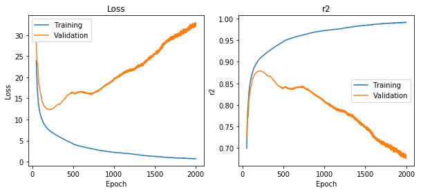

```
-- Minimum Validation Loss --
Loss:  12.294610977172852
Epoch: 209

-- Maximum Validation r2 --
r2:    0.8791505694389343
Epoch: 209
```

```python
#####################################################
# Design and Train Model
#####################################################

np.random.seed(1)
set_random_seed(1)

model_1 = Sequential()
model_1.add(Dense(32, input_shape=(13,), activation='relu'))
model_1.add(Dense(16, activation='relu'))
model_1.add(Dense(1, activation='linear'))

opt = keras.optimizers.Adam(lr=0.01)
model_1.compile(loss='mean_squared_error', optimizer=opt, metrics=[r2])

h = model_1.fit(Xs_train, y_train, batch_size=500, epochs=2000, validation_data = [Xs_val, y_val], verbose=0)

#####################################################
# Visualize Training Progress
#####################################################

m = 50
rng = range(m, len(h.history['loss']))

plt.figure(figsize=[10,4])
plt.subplot(1,2,1)
plt.plot(rng, h.history['loss'][m:], label='Training')
plt.plot(rng, h.history['val_loss'][m:], label='Validation')
plt.title('Loss')
plt.ylabel('Loss')
plt.xlabel('Epoch')
plt.legend()

plt.subplot(1,2,2)
plt.plot(rng, h.history['r2'][m:], label='Training')
plt.plot(rng, h.history['val_r2'][m:], label='Validation')
plt.title('r2')
plt.ylabel('r2')
plt.xlabel('Epoch')
plt.legend()
plt.show()

#####################################################
# Find Minimum Validation Loss
#####################################################

print('-- Minimum Validation Loss --')
print('Loss: ', min(h.history['val_loss']))
print('Epoch:', np.argmin(h.history['val_loss']))
print()

print('-- Maximum Validation r2 --')
print('r2:   ', max(h.history['val_r2']))
print('Epoch:', np.argmax(h.history['val_r2']))
```

## Retrain Model with Fewer Epochs

```python
np.random.seed(1)
set_random_seed(1)

model_2 = Sequential()
model_2.add(Dense(32, input_shape=(13,), activation='relu'))
model_2.add(Dense(16, activation='relu'))
model_2.add(Dense(1, activation='linear'))

opt = keras.optimizers.Adam(lr=0.01)
model_2.compile(loss='mean_squared_error', optimizer=opt, metrics=[r2])

h = model_2.fit(Xs_train, y_train, batch_size=500, epochs=215, validation_data = [Xs_val, y_val], verbose=0)

tr_results = model_2.evaluate(Xs_train, y_train, verbose=0)
va_results = model_2.evaluate(Xs_val, y_val, verbose=0)

print('Training Loss:  ', tr_results[0])
print('Training r2:    ', tr_results[1], '\n')

print('Validation Loss:', va_results[0])
print('Validation r2:  ', va_results[1])
```

```
Training Loss:   7.33555284349045
Training r2:     0.8938835619306407

Validation Loss: 12.319281096505646
Validation r2:   0.8616513769225319
```

## Apply L2 Regularization

We will now train the same model, this time adding an L2 regularization term to the loss. In this scenario, our learning algorithm will try to minimize the following function:

$$\Large Loss = \frac{1}{n} SSE + \lambda \sum \left[w^{(d)}_{i,j} \right]^2$$

Where $w^{(d)}_{i,j}$ is the weight that leads from node `i` in layer `d-1` to node `j` in layer `d`. The sum in the penalty term is only calculated over the non-bias weights.

The constant $\lambda$ is a model hyperparameter that we are free to choose.

```python
from keras import regularizers
```

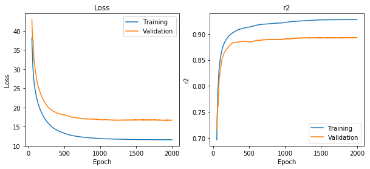

```
-- Minimum Validation Loss --
Loss:  16.652097702026367
Epoch: 1896

-- Maximum Validation r2 --
Loss:  0.8931909203529358
Epoch:    1896
```

```python
#####################################################
# Design and Train Model
#####################################################

np.random.seed(1)
set_random_seed(1)

model_3 = Sequential()
model_3.add(Dense(32, input_shape=(13,), activation='relu', kernel_regularizer=regularizers.l2(0.2)))
model_3.add(Dense(16, activation='relu', kernel_regularizer=regularizers.l2(0.2)))
model_3.add(Dense(1, activation='linear', kernel_regularizer=regularizers.l2(0.2)))

opt = keras.optimizers.Adam(lr=0.01)
model_3.compile(loss='mean_squared_error', optimizer=opt, metrics=[r2])

h = model_3.fit(Xs_train, y_train, batch_size=500, epochs=2000, validation_data = [Xs_val, y_val], verbose=0)

#####################################################
# Visualize Training Progress
#####################################################

m = 50
rng = range(m, len(h.history['loss']))

plt.figure(figsize=[10,4])
plt.subplot(1,2,1)
plt.plot(rng, h.history['loss'][m:], label='Training')
plt.plot(rng, h.history['val_loss'][m:], label='Validation')
plt.title('Loss')
plt.ylabel('Loss')
plt.xlabel('Epoch')
plt.legend()

plt.subplot(1,2,2)
plt.plot(rng, h.history['r2'][m:], label='Training')
plt.plot(rng, h.history['val_r2'][m:], label='Validation')
plt.title('r2')
plt.ylabel('r2')
plt.xlabel('Epoch')
plt.legend()
plt.show()

#####################################################
# Find Minimum Validation Loss
#####################################################

print('-- Minimum Validation Loss --')
print('Loss: ', min(h.history['val_loss']))
print('Epoch:', np.argmin(h.history['val_loss']))
print()

print('-- Maximum Validation r2 --')
print('Loss: ', max(h.history['val_r2']))
print('Epoch:   ', np.argmax(h.history['val_r2']))
```

## Apply Dropout Regularization

```python
from keras.layers import Dropout
```

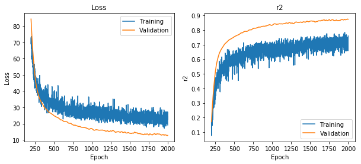

```
-- Minimum Validation Loss --
Loss:  12.617439270019531
Epoch: 1992

-- Maximum Validation r2 --
Loss:  0.8759773969650269
r2:    1992
```

```python
#####################################################
# Design and Train Model
#####################################################

np.random.seed(1)
set_random_seed(1)

model_4 = Sequential()
model_4.add(Dense(32, input_shape=(13,), activation='relu'))
model_4.add(Dropout(0.1))
model_4.add(Dense(16, activation='relu'))
model_4.add(Dropout(0.1))
model_4.add(Dense(1, activation='linear'))

opt = keras.optimizers.Adam(lr=0.001)
model_4.compile(loss='mean_squared_error', optimizer=opt, metrics=[r2])

h = model_4.fit(Xs_train, y_train, batch_size=500, epochs=2000, validation_data = [Xs_val, y_val], verbose=0)

#####################################################
# Visualize Training Progress
#####################################################

m = 200
rng = range(m, len(h.history['loss']))

plt.figure(figsize=[10,4])
plt.subplot(1,2,1)
plt.plot(rng, h.history['loss'][m:], label='Training')
plt.plot(rng, h.history['val_loss'][m:], label='Validation')
plt.title('Loss')
plt.ylabel('Loss')
plt.xlabel('Epoch')
plt.legend()

plt.subplot(1,2,2)
plt.plot(rng, h.history['r2'][m:], label='Training')
plt.plot(rng, h.history['val_r2'][m:], label='Validation')
plt.title('r2')
plt.ylabel('r2')
plt.xlabel('Epoch')
plt.legend()
plt.show()

#####################################################
# Find Minimum Validation Loss
#####################################################

print('-- Minimum Validation Loss --')
print('Loss: ', min(h.history['val_loss']))
print('Epoch:', np.argmin(h.history['val_loss']))
print()

print('-- Maximum Validation r2 --')
print('Loss: ', max(h.history['val_r2']))
print('r2:   ', np.argmax(h.history['val_r2']))
```

## Evaluate Testing Performance

```python
testing_results = model_3.evaluate(Xs_test, y_test, verbose=0)

print('Testing Loss: ', testing_results[0])
print('Testing r2:   ', testing_results[1])
```

```
Testing Loss:  19.094673867319145
Testing r2:    0.8409638159415301
```